# [과제4] 최준혁

최준혁

2019 6 10

## ggplot 연습문제

##### 1. mpg 데이터의 cty(도시 연비)와 hwy(고속도로 연비) 간에 어떤 관계가 있는지 알아보려고 합니다. x축은 cty, y축은 hwy로 된 산점도를 만들어 보세요.

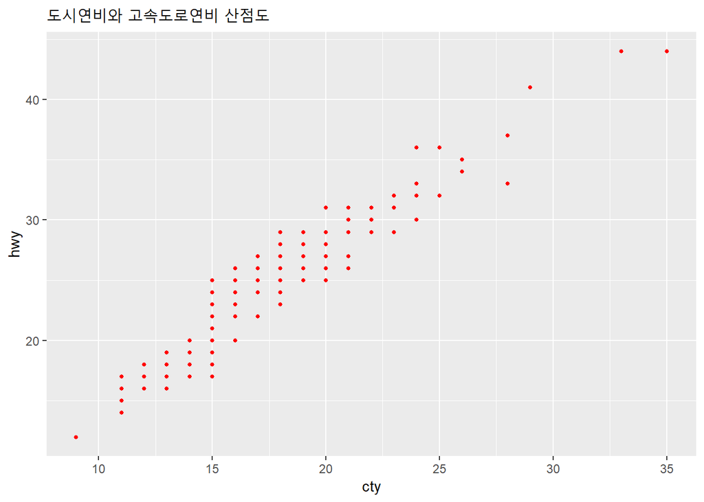

```r
library(ggplot2)
library(dplyr)
ggplot(mpg, aes(x=cty, y=hwy)) +
  geom_point(size=1, color='red') +
  ggtitle('도시연비와 고속도로연비 산점도')
```

##### 2. 미국 지역별 인구통계 정보를 담은 ggplot2 패키지의 midwest 데이터를 이용해서 전체 인구와 아시아인 인구 간에 어떤 관계가 있는지 알아보려고 합니다. x축은 poptotal(전체 인구), y축은 popasian(아시아인 인구)으로 된 산점도를 만들어 보세요. 전체 인구는 50만 명 이하, 아시아인 인구는 1만 명 이하인 지역만 산점도에 표시되게 설정하세요.

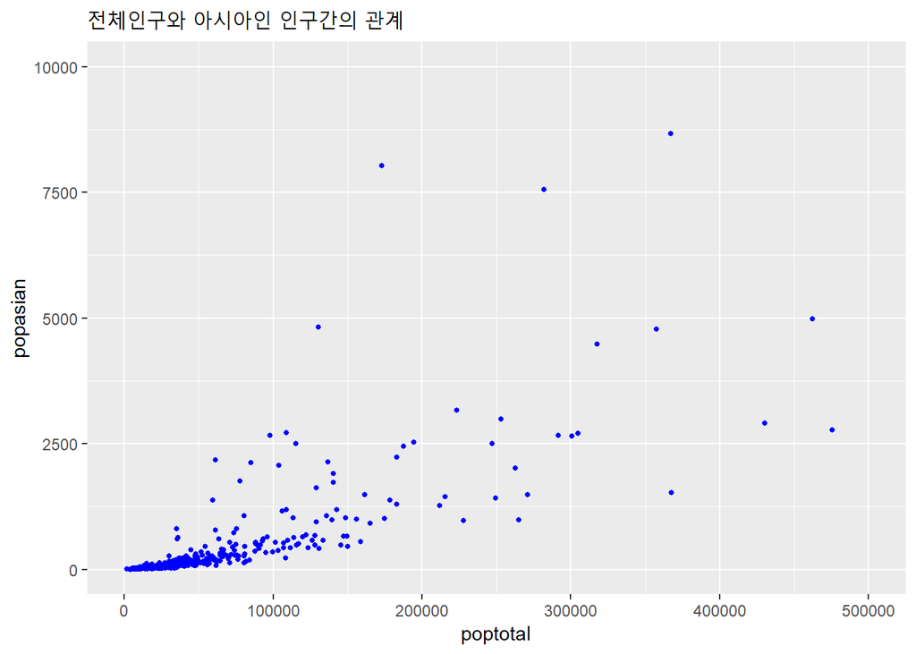

```r
midw <- filter(midwest, poptotal <= 500000 && popasian <= 10000)
options(scipen = 10)
ggplot(midw, aes(x=poptotal, y=popasian)) +
  xlim(0,500000) + ylim(0,10000)+
  geom_point(size=1, color='blue')+
  ggtitle('전체인구와 아시아인 인구간의 관계')
```

##### 3. 어떤 회사에서 생산한 “suv” 차종의 도시 연비가 높은지 알아보려고 합니다. “suv” 차종을 대상으로 평균 cty(도시 연비)가 가장 높은 회사 다섯 곳을 막대 그래프로 표현해 보세요. 막대는 연비가 높은 순으로 정렬하세요.

```r
avg_cty<-mpg %>%
  filter(class %in% c('suv')) %>%
  group_by(manufacturer) %>%
  summarise(average_cty = mean(cty)) %>%
  arrange(desc(average_cty))%>%
  head(5)
avg_cty
```

```
## # A tibble: 5 x 2
##   manufacturer average_cty
##   <chr>              <dbl>
## 1 subaru              18.8
## 2 toyota              14.4
## 3 nissan              13.8
## 4 jeep                13.5
## 5 mercury             13.2
```

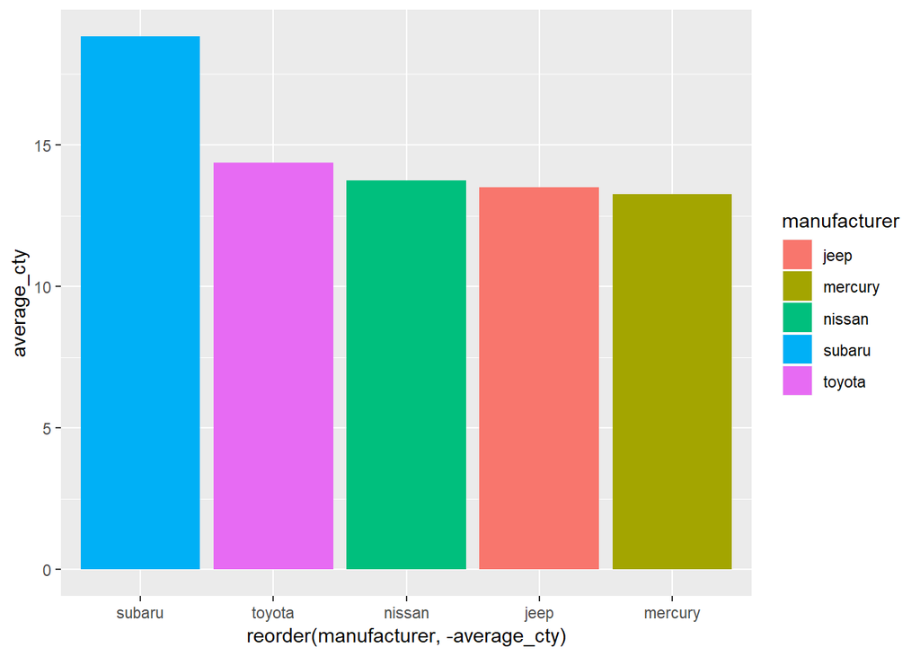

```r
ggplot(avg_cty, aes(x=reorder(manufacturer, -average_cty),
  y=average_cty, fill=manufacturer)) +
  geom_col()
```

##### 4. 자동차 중에서 어떤 class(자동차 종류)가 가장 많은지 알아보려고 합니다. 자동차 종류별 빈도를 표현한 막대 그래프를 만들어 보세요.

```r
mpg %>%
  group_by(class) %>%
  summarise(n=n())->fbar; fbar
```

```
## # A tibble: 7 x 2
##   class          n
##   <chr>      <int>
## 1 2seater        5
## 2 compact       47
## 3 midsize       41
## 4 minivan       11
## 5 pickup        33
## 6 subcompact    35
## 7 suv           62
```

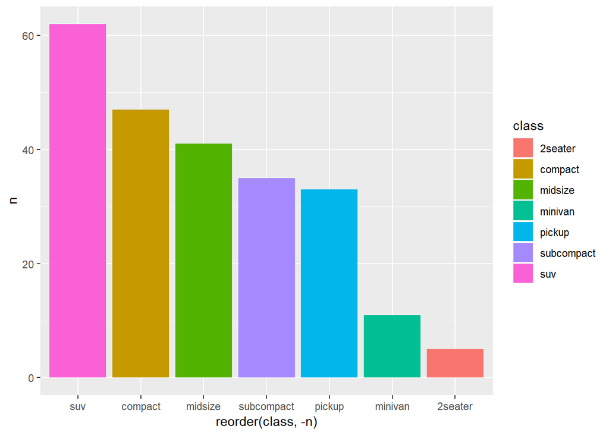

```r
ggplot(fbar, aes(x=reorder(class, -n), y=n, fill=class)) +
  geom_col()
```

##### 5. economics 데이터를 이용해서 psavert(개인 저축률)가 시간에 따라서 어떻게 변해왔는지 알아보려고 합니다. 시간에 따른 개인 저축률의 변화를 나타낸 시계열 그래프를 만들어 보세요.

```r
economics
```

```
## # A tibble: 574 x 6
##    date         pce    pop psavert uempmed unemploy
##    <date>     <dbl>  <int>   <dbl>   <dbl>    <int>
##  1 1967-07-01  507. 198712    12.5     4.5     2944
##  2 1967-08-01  510. 198911    12.5     4.7     2945
##  3 1967-09-01  516. 199113    11.7     4.6     2958
##  4 1967-10-01  513. 199311    12.5     4.9     3143
##  5 1967-11-01  518. 199498    12.5     4.7     3066
##  6 1967-12-01  526. 199657    12.1     4.8     3018
##  7 1968-01-01  532. 199808    11.7     5.1     2878
##  8 1968-02-01  534. 199920    12.2     4.5     3001
##  9 1968-03-01  545. 200056    11.6     4.1     2877
## 10 1968-04-01  545. 200208    12.2     4.6     2709
## # ... with 564 more rows
```

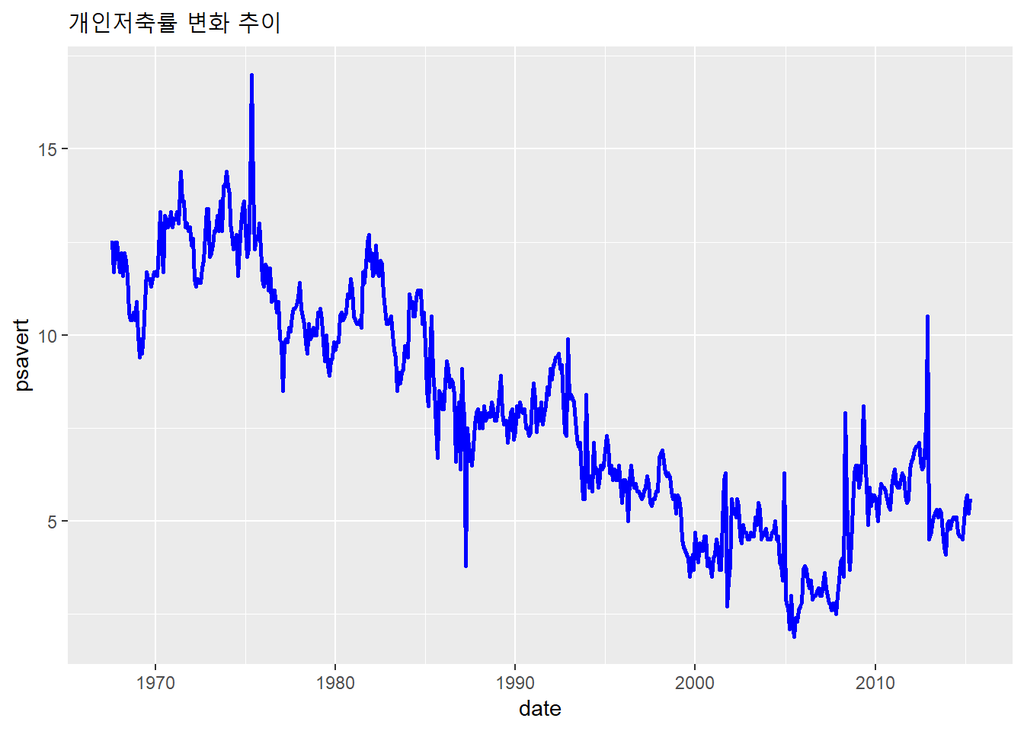

```r
View(economics)
ggplot(economics, aes(x=date, y=psavert)) +
  geom_line(color="blue", size=1)+
  ggtitle("개인저축률 변화 추이")
```

##### 6. class(자동차 종류)가 “compact”, “subcompact”, “suv”인 자동차의 cty(도시 연비)가 어떻게 다른지 비교해보려고 합니다. 세 차종의 cty를 나타낸 상자 그림을 만들어보세요.

```r
css<-mpg %>%
  filter(class %in% c('compact', 'subcompact','suv')) %>%
  group_by(class)
css
```

```
## # A tibble: 144 x 11
## # Groups:   class [3]
##    manufacturer model displ  year   cyl trans drv     cty   hwy fl    class
##    <chr>        <chr> <dbl> <int> <int> <chr> <chr> <int> <int> <chr> <chr>
##  1 audi         a4      1.8  1999     4 auto~ f        18    29 p     comp~
##  2 audi         a4      1.8  1999     4 manu~ f        21    29 p     comp~
##  3 audi         a4      2    2008     4 manu~ f        20    31 p     comp~
##  4 audi         a4      2    2008     4 auto~ f        21    30 p     comp~
##  5 audi         a4      2.8  1999     6 auto~ f        16    26 p     comp~
##  6 audi         a4      2.8  1999     6 manu~ f        18    26 p     comp~
##  7 audi         a4      3.1  2008     6 auto~ f        18    27 p     comp~
##  8 audi         a4 q~   1.8  1999     4 manu~ 4        18    26 p     comp~
##  9 audi         a4 q~   1.8  1999     4 auto~ 4        16    25 p     comp~
## 10 audi         a4 q~   2    2008     4 manu~ 4        20    28 p     comp~
## # ... with 134 more rows
```